# Math 421 - Midterm

## III. Predictive Models

Continue with the data from part I. Make sure you do not have any missing values in the data. Use the follows as the target and input variables:

```r
colSums(is.na(df))
```

```
##      yod pay_ub92      age      sex raceethn provider      moa      yoa
##        0        0        0        0        0        0        0        0
##      mod  admtype  asource      los  service      icu      ccu dispub92
##        0        0        0        0        0        0        0        0
##    payer      drg   trandb   randbg   randbs      orr     anes      seq
##        0        0        0        0        0        0        0        0
##      lab    dtest     ther    blood     phar    other   patcon    bwght
##        0        0        0        0        0        0        0        0
##    total      tot ecodub92     b_wt pt_state diag_adm  ancilar   campus
##        0        0        0        0        0        0        0        0
##   er_fee  er_chrg  er_mode obs_chrg psycchrg   season
##        0        0        0        0        0    11309
```

```r
drop_na(df)
```

```
## # A tibble: 120,169 × 46
##      yod pay_ub92   age sex   raceethn provider   moa   yoa   mod admtype
##    <dbl>    <dbl> <dbl> <chr> <chr>    <chr>    <dbl> <dbl> <dbl> <chr>
##  1    18        6    50 2     "1"      7214        12    17     1 2
##  2    18       13     0 1     "1"      7214        12    17     1 4
##  3    18        4     0 2     "9"      7214        12    17     1 4
##  4    18        9    25 2     "1"      7214        12    17     1 2
##  5    18        6     0 2     "3"      7214        12    17     1 4
##  6    18        9    37 2     "1"      7214        12    17     1 3
##  7    18        6    37 2     ""       7214        12    17     1 3
##  8    18        6    33 2     ""       7214        12    17     1 3
##  9    18        4    27 2     "1"      7214        12    17     1 3
## 10    18        9    28 2     ""       7214        12    17     1 3
## # ℹ 120,159 more rows
## # ℹ 36 more variables: asource <chr>, los <dbl>, service <chr>, icu <chr>,
## #   ccu <chr>, dispub92 <chr>, payer <chr>, drg <dbl>, trandb <chr>,
## #   randbg <chr>, randbs <chr>, orr <chr>, anes <chr>, seq <chr>, lab <chr>,
## #   dtest <chr>, ther <chr>, blood <chr>, phar <chr>, other <chr>,
## #   patcon <chr>, bwght <chr>, total <chr>, tot <dbl>, ecodub92 <chr>,
## #   b_wt <chr>, pt_state <chr>, diag_adm <chr>, ancilar <chr>, campus <chr>, …
```

*Target Variable*: Create the target variable taking value of

- `low` if the total charge of a patient (`tot`) is smaller than the median of the total charge, and
- `high` otherwise.

```r
df = df %>%
  mutate(median_tot = median(tot)) %>%
  mutate(target = case_when(
  tot < median_tot ~ "low",
  tot >= median_tot ~ "high"
))
```

*Input Variables*:

- “age”,“sex”,“raceethn”,“provider”,“moa”,“mod”,“admtype”,“campus”, ‘los’

```r
df = df %>%
  select(age, sex, raceethn, provider, moa, mod, admtype, campus, los, median_tot, target)
```

```r
library(caret)
df = df %>%
  filter(raceethn=='') %>%
  mutate(sex = as.factor(sex),
         target = as.factor(target),
         raceethn = as.factor(raceethn),
         provider = as.factor(provider),
         moa = as.factor(moa),
         mod = as.factor(moa),
         admtype = as.factor(admtype),
         campus = as.factor(campus))

set.seed(2020)

splitIndex = createDataPartition(df$target, p = 0.90, list = FALSE)

df_train = df[ splitIndex,]
df_test = df[-splitIndex,]
```

2. Train a decision tree using `rpart`. Plot the decision tree. Plot the variable importance ranked by the tree.

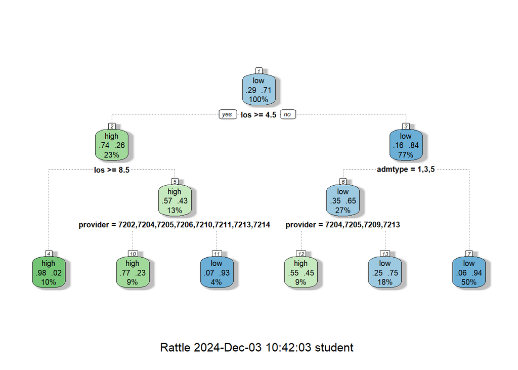

```r
library(rpart)
tree_model = rpart(target ~ ., data = df_train,
                 control = rpart.control(maxdepth = 3))
library(rattle)
fancyRpartPlot(tree_model)
```

```r
tree_model$variable.importance
```

```
##         los    provider     admtype         age      campus         moa
## 495.7507915 209.2842979 113.2667341  64.2964994  25.4019301   0.7791236
##         mod
##   0.7791236
```

3. Using caret for this question. Set `Training Control` to be: Use Cross-Validation of 5 folds across all models. Train & tune at least 2 different models (i.e. two different values for `method=` in the train function of caret). Plot the hyper-parameter tuning plots for each model.

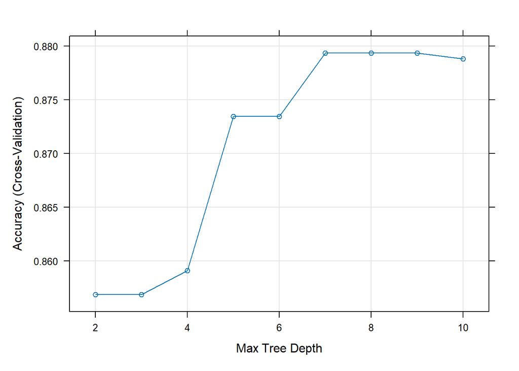

```r
df_train= df_train %>% select(-raceethn)

tuneGrid = expand.grid(maxdepth = 2:10)

trControl = trainControl(method = "cv",
                         number = 5)

tree_approach2 <- train(target~., data=df_train,
                                method = "rpart2",
                                trControl = trControl,
                                tuneGrid = tuneGrid)


trControl = trainControl(method = "cv",
                         number = 5)
tuneGrid = expand.grid(mtry = 2:4,
                       splitrule = c('gini', 'extratrees'),
                       min.node.size = c(1:10))
forest_ranger <- train(target~., data=df_train,
                    method = "ranger",
                    trControl = trControl,
                    tuneGrid = tuneGrid)

plot(tree_approach2)
```

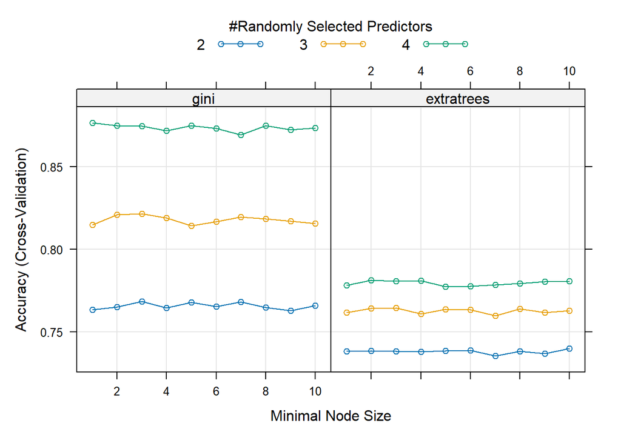

```r
plot(forest_ranger)
```

4. Plot the comparison of the models in 3.

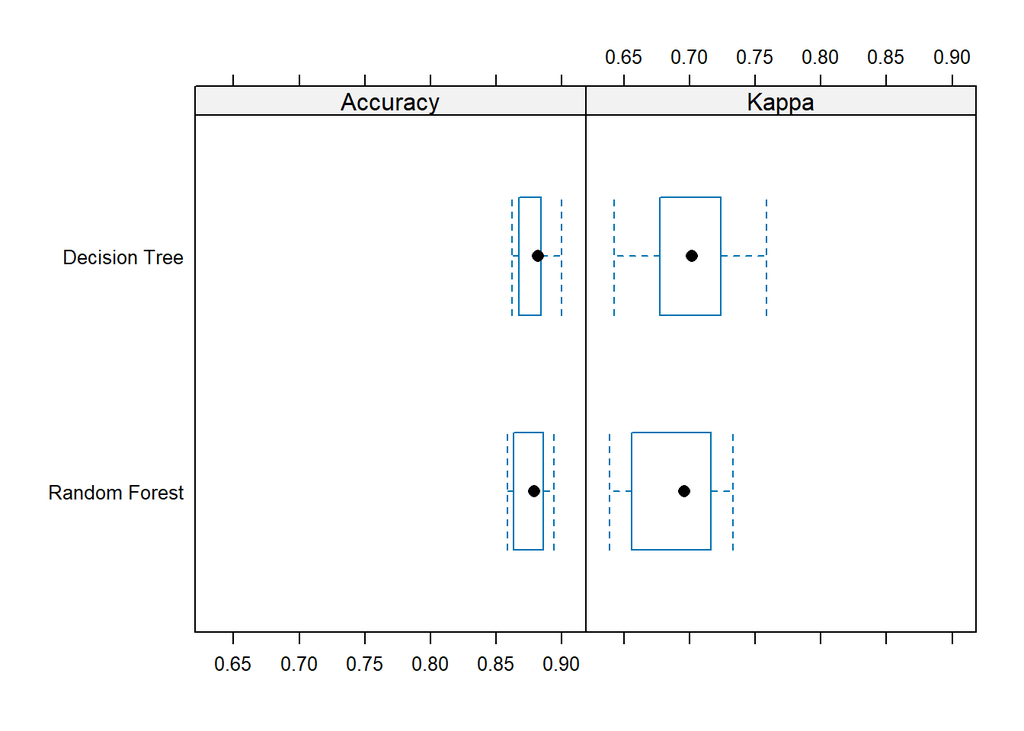

```r
results <- resamples(list('Decision Tree' = tree_approach2,
                          'Random Forest' = forest_ranger))

bwplot(results)
```

5. What is your final selection for the model? Test the accuracy of your final model on the test data.

```r
pred <- predict(forest_ranger, df_test)
cm <- confusionMatrix(data = pred, reference = df_test$target, positive = "high")
cm$overall[1]
```

```
##  Accuracy
## 0.8959391
```

```r
pred <- predict(tree_approach2, df_test)
cm <- confusionMatrix(data = pred, reference = df_test$target, positive = "high")
cm$overall[1]
```

```
##  Accuracy
## 0.8984772
```

```r
## Choose Decision Tree since it has a slightly higher accuracy
```

6. Create another `target` variable (binary), decide the input variables and redo 1 to 5.

```r
dfa = df %>%
  mutate(target = sex) %>%
  mutate(sex = as.factor(sex),
         target = as.factor(target),
         raceethn = as.factor(raceethn),
         provider = as.factor(provider),
         moa = as.factor(moa),
         mod = as.factor(moa),
         admtype = as.factor(admtype),
         campus = as.factor(campus))
```

```r
dfa = dfa %>%
  select(age, -sex, provider, moa, mod, admtype, los, target)
```

[figure not shown]

```r
set.seed(2020)

splitIndex = createDataPartition(dfa$target, p = 0.80, list = FALSE)

dfa_train = dfa[ splitIndex,]
dfa_test = dfa[-splitIndex,]

library(rpart)
tree_model = rpart(target ~ ., data = dfa_train,
                 control = rpart.control(maxdepth = 3))
library(rattle)
fancyRpartPlot(tree_model)
```

```r
tree_model$variable.importance
```

```
##  provider   admtype       age       los       moa       mod
## 143.82950  97.25438  79.81437  40.66258  10.62063  10.62063
```